# WHOOP: A Journey Into Unocking Human Performance

### Research Question:

#### Does Whoop allow the user to "unlock their human performance" as specified in their mission statement?

### Introduction

This early phases of this project began months ago when Ben decided to purchase a whoop. A whoop is a fitness wearable that claims to improve the health and performance of it's wearers by utilizing an array of biomarkers regarding sleep and fitness. On the company's site, whoop.com, Whoop claims to reduce the wearers heart rate, increase their heart rate variability, and improve their sleep in a significant manner after four months. Our goal is to see if we have been able to reap these benefits, after using the product.

If, after four months, Ben's heart rate decreases 4.4 beats per minute, heart rate variability increases by 8 milliseconds, and sleep improves by 41 minutes, then we can assume that by Whoop's definition, Ben has unlocked his human performance. The question that remains will be if Ben feels that way as well.

After collecting, analyzing and calculating significance with our data set, it was determined that Ben's biomarkers did not improve in the way that Whoop articulated they would. Because of this, we fail to prove that Ben was able to "unlock his human performance" through Whoop's definition. However, through this experience Ben has developed a better understanding of his biomarkers and how they are affected by his lifestyle choices. Although his human potential wasn't necessarily unlocked, through this experience, Ben feels that he at least knows where he could find the key.

### Preregistered Analyses

- Strain and Calories: We predict strain and calories will be positively correlated.
- Strain and Sleep Performance: We predict higher strain will positively correlate with sleep performance.
- HRV and Recovery Score: We predict HRV correlates positively with recovery score.
- Resting Heart Rate and Recovery: We predict heart rate increasing will negatively correlate with recovery score.
- Sleep duration and Strain on the following day: We predict sleep time and strain will have a correlation close to 0.

```python
import pandas as pd
whoop = pd.read_csv('whoop.csv')
whoop
```

|  | Unnamed: 0 | date | strain | recovery | sleep score | rhr | average hr | max hr | kj | respiratory rate | hrv (ms) | sleep (hr) | recovery type | day of week | calories | sleep start | sleep end |
| --- | --- | --- | --- | --- | --- | --- | --- | --- | --- | --- | --- | --- | --- | --- | --- | --- | --- |
| 0 | 1 | 2020-06-26 | 8.646764 | 48.0 | 52.0 | 66.0 | 74 | 172 | 9164.9500 | 15.3809 | 86.3560 | 4.730098 | Yellow | 4 Thu | 2190.475621 | 1.593156e+12 | 1.593177e+12 |
| 1 | 2 | 2020-06-27 | 11.267974 | 47.0 | 53.0 | 63.0 | 73 | 182 | 8728.9000 | 15.1758 | 84.4836 | 5.111626 | Yellow | 5 Fri | 2086.257170 | 1.593244e+12 | 1.593264e+12 |
| 2 | 3 | 2020-06-28 | 17.959551 | 88.0 | 57.0 | 42.0 | 108 | 183 | 13709.5000 | 13.5645 | 174.2390 | 5.587007 | Green | 6 Sat | 3276.649140 | 1.593322e+12 | 1.593346e+12 |
| 3 | 4 | 2020-06-29 | 14.670738 | 89.0 | 74.0 | 50.0 | 72 | 180 | 11663.9000 | 14.5020 | 162.0630 | 7.627067 | Green | 0 Sun | 2787.739006 | 1.593405e+12 | 1.593435e+12 |
| 4 | 5 | 2020-06-30 | 8.300598 | 89.0 | 69.0 | 44.0 | 70 | 152 | 8791.8300 | 13.6523 | 163.2510 | 6.859964 | Green | 1 Mon | 2101.297801 | 1.593492e+12 | 1.593521e+12 |
| ... | ... | ... | ... | ... | ... | ... | ... | ... | ... | ... | ... | ... | ... | ... | ... | ... | ... |
| 142 | 143 | 2020-11-15 | 8.736535 | 22.0 | 42.0 | 51.0 | 67 | 149 | 7530.1300 | 14.4141 | 82.7509 | 3.593479 | Red | 6 Sat | 1799.744264 | 1.605433e+12 | 1.605448e+12 |
| 143 | 144 | 2020-11-16 | 12.064644 | 91.0 | 76.0 | 41.0 | 70 | 155 | 11679.3000 | 14.1211 | 178.0950 | 6.969580 | Green | 0 Sun | 2791.419694 | 1.605500e+12 | 1.605528e+12 |
| 144 | 145 | 2020-11-17 | 10.798262 | 58.0 | 74.0 | 48.0 | 69 | 156 | 9276.7600 | 14.9414 | 132.4340 | 6.319614 | Yellow | 1 Mon | 2217.198853 | 1.605598e+12 | 1.605623e+12 |
| 145 | 146 | 2020-11-18 | 14.740801 | 56.0 | 66.0 | 49.0 | 75 | 158 | 13658.7000 | 13.5645 | 124.6330 | 6.334052 | Yellow | 2 Tue | 3264.507648 | 1.605676e+12 | 1.605702e+12 |
| 146 | 147 | 2020-11-19 | 2.134574 | 14.0 | 31.0 | 65.0 | 61 | 112 | 2193.2002 | 15.0000 | 72.8230 | 2.975854 | Red | 3 Wed | 524.187428 | 1.605775e+12 | 1.605788e+12 |

147 rows × 17 columns

### Acknowledgements

We were able to download Ben's Whoop data by using an excel sheet app created by PeloTech on Github, the app is open source and coded in javascript. It is available here: https://github.com/pelo-tech/whoop-google-sheets

The app allows us to import the Whoop data into a CSV file by passing our login information through the API. This is named rawwhoop.csv, and is saved to our github.

### Data Description

#### What are the observations (rows) and the attributes (columns)?

The observations are days in chronological order, and the attributes are a variety of measured and calculated recordings taken from Whoop's API like sleep duration, average heart rate, max heart rate, and respiratory rate.

#### Why was this dataset created?

This dataset was created due to Ben's curiosity into his body's functions throughout each day. While the Whoop provides an ergonomic GUI for analyzing the data, the question remained if there was any analysis being missed by the app. By analyzing the raw csv, we can see for ourselves if there are any relationships not displayed by the GUI.

#### Who funded the creation of the dataset?

The creation of this dataset was funded by Ben. He pays $30 per month for the Whoop membership, which comes with the free wearable that tracks strain, recovery, and sleep by using an extremely accurate heartrate and movement sensor, using LEDs and a 3 axis accelerometer.

#### What processes might have influenced what data was observed and recorded and what was not?

The Whoop strap 3.0 has a 5 day battery, is waterproof, and has no interface. It is designed to never be taken off. Because of the nature of this 24/7 data collection, there are no gaps in the observed data, and therefore no disgression on our behalf when choosing what data to include in our set. That being said, there is the inherent issue that the designers of Whoop's software have some say in what gets factored into calculating the various markers, recovery, strain, sleep score etc. Their process of data gathering and cleaning would be the single largest variable in determining what was recorded.

#### What preprocessing was done, and how did the data come to be in the form that you are using?

We located a third party app online that scraped the Whoop HTML app, and converted the data into an excel file, which we were then able to save as a CSV. There was no preprocessing done by the software, however the preprocessing done by Whoop themselves was significant. For example, in order to calculate strain, the app uses a number of datapoints such as heart rate, and heart rate variability, both recorded multiple times a second by the device. The raw datapoints are available to the user to some degree, but there is a significant amount of calculations done on the back-end to reach strain, sleep, and recovery scores.

#### If people are involved, were they aware of the data collection and if so, what purpose did they expect the data to be used for?

Ben was aware of the data being collected and even funding it. In fact, one of the variables measured is recovery score. This is measured through a function that computes resting heart rate, sleep in hours, and a host of other variables that would give a scaled number from 1 to 100 that represents the recovery from the previous day's physical strain. He used Whoop to optimize physical recovery and growth, thus as he viewed his data being collected he altered his daily choices regarding physical activity. For example, on a day where Ben woke up with a 90 percent recovery score, he would be more inclined to go for a challenging run, or perhaps increase the amount of weight he trained with. Vice Versa, on a 15 percent recovery day, Ben would be encouraged to take an ice bath or nap. This is an essential part of "Unlocking Human Performance" as advertised by Whoop. Their hypothesis is that by understanding your body's physiological markers, you can better tailor your activities to achieve peak performance. One of the biggest questions we aim to answer is whether or not this is actually the case.

#### Was any preprocessing/cleaning/labeling of the data done?

Yes there was preprocessing done to the data. We created a cleaning function as opposed to cleaning the set by hand which allows us to update our project with more data collected by whoop until the day it is due. The cleaning function formats the titles to lowercase, and strips outer white space. Then, it discards the workouts, comments, hrv and sleep duration columns. The reason for discarding the workouts and comments columns are due to a quirk in the API used to collect data, and these columns were completely empty or contained 0 for every entry. The hrv and sleep duration columns are dropped because this data is already stored in other columns in a more readable manner, hrv (in milliseconds) and sleep (hours) respectively.

### Data Limitations

Identify any potential problems with your dataset.

Problems with the data set include the accuracy of the data as measured by the Whoop Strap 3.0. The device potentially mismeasured the data that we collected. However, we expect this data to be accurate and there is no reason to suspect that there are inaccuracies in the dataset. Additionally, It is difficult, however possible, to prove or disprove our research question due to the limitations of what the Whoop Strap 3.0 can measure. Intially, this was considered a data limitation; however, Whoop quanitfies 'unlocking your human performance'. According to Whoop.com, unlocking your human performance consists of reducing resting heart rate (RHR) by 4.4 BPM, heart rate variablilty (HRV) by 8 milliseconds, and increasing sleep by 41 minutes per night. Thus, we can quantify 'unlocking your human perfomance'.

Another important aspect to look at is the fact that Ben looked at his data everyday. This influenced his daily decisions regarding physical activity. These daily decisions that Ben made influenced the future collection of data. For example, after a day of hiking Ben's strain score was high the next morning. Therefore, he decided to take the day off which influenced data collection.

Ben was infleunced by his ability to look at his data everyday, but this doesn't thwart the data's validity. The Whoop Strap 3.0 is made for the purpose of training and recovering effectively, which is defined by your strain and recovery score, respectively. When Ben looks at his daily recovery score and makes desicions regarding his exersize for the day, Ben is optimizing his training. Ben is acting in his own self interest as any reasonable economic player would. If done properly, Whoop claims on their website that after four months users will experience a litany of positive health benefits like decresed resting heart rate, better sleep, and fewer injuries.

There are few, if any, data limitations for our data set given the accuracy and purpose of the Whoop Strap 3.0.

### Exploratory Data Analysis

```python
import matplotlib.pyplot as plt
def plotandcorrelate(x,y,title):
    xlabel = str(x.name)
    ylabel = str(y.name)
    plt.xlabel(xlabel)
    plt.ylabel(ylabel)
    plt.title(title)
    plt.scatter(x,y)
    plt.show()
    print("The correlation between {} and {} is: ".format(xlabel,ylabel) + str(x.corr(y)))
    print("The covariance between {} and {} is: ".format(xlabel,ylabel) + str(x.cov(y)))
```

```python
def boxplot(column):
    print("5 Number Summary for {}".format(column))
    print(whoop[column].describe())
    whoop.boxplot(column)
    plt.show()
```

```python
def groupedboxplot(column, by):
    print("5 Number Summary for {} grouped by {}".format(column, by))
    print(whoop[column].groupby(whoop[by]).describe())
    whoop.boxplot(column, by)
    plt.show()
```

Once again, we are creating functions for analysis, mostly for ease of use. The first, plotandcorrelate(), displays a scatterplot of two columns, and prints the correlation. The second, boxplot(), prints a boxplot. The third, groupedboxplot(), allows the user to group it by another variable, and then displays the boxplot and 5 number summary.

```python
best_day_ever = whoop[whoop['strain'] == whoop['strain'].max()]
best_day_ever
```

|  | Unnamed: 0 | date | strain | recovery | sleep score | rhr | average hr | max hr | kj | respiratory rate | hrv (ms) | sleep (hr) | recovery type | day of week | calories | sleep start | sleep end |
| --- | --- | --- | --- | --- | --- | --- | --- | --- | --- | --- | --- | --- | --- | --- | --- | --- | --- |
| 11 | 12 | 2020-07-07 | 19.715087 | 82.0 | 72.0 | 58.0 | 120 | 190 | 16676.6 | 14.5312 | 209.662 | 5.846886 | Green | 1 Mon | 3985.803059 | 1.594097e+12 | 1.594120e+12 |

```python
worst_day_ever = whoop[whoop['strain'] == whoop['strain'].min()]
worst_day_ever
```

|  | Unnamed: 0 | date | strain | recovery | sleep score | rhr | average hr | max hr | kj | respiratory rate | hrv (ms) | sleep (hr) | recovery type | day of week | calories | sleep start | sleep end |
| --- | --- | --- | --- | --- | --- | --- | --- | --- | --- | --- | --- | --- | --- | --- | --- | --- | --- |
| 146 | 147 | 2020-11-19 | 2.134574 | 14.0 | 31.0 | 65.0 | 61 | 112 | 2193.2002 | 15.0 | 72.823 | 2.975854 | Red | 3 Wed | 524.187428 | 1.605775e+12 | 1.605788e+12 |

### Strain and Calories

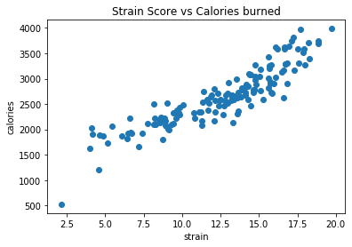

```
The correlation between strain and calories is: 0.9053963345645968
The covariance between strain and calories is: 1988.3011135290506
```

```python
plotandcorrelate(whoop['strain'], whoop['calories'], "Strain Score vs Calories burned")
```

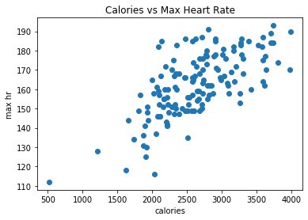

```
The correlation between calories and max hr is: 0.6851696587855521
The covariance between calories and max hr is: 6446.885991201553
```

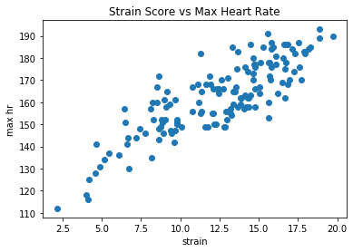

```
The correlation between strain and max hr is: 0.8405456292332065
The covariance between strain and max hr is: 52.469467700579386
```

```python
plotandcorrelate(whoop['calories'], whoop['max hr'], "Calories vs Max Heart Rate")
plotandcorrelate(whoop['strain'], whoop['max hr'], "Strain Score vs Max Heart Rate")
```

In these plots, we can see that the correlation between Strain and max heart rate is stronger than between calories and max heart rate, though both correlate positively.

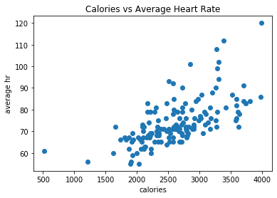

```
The correlation between calories and average hr is: 0.6492208577084716
The covariance between calories and average hr is: 3969.37656389965
```

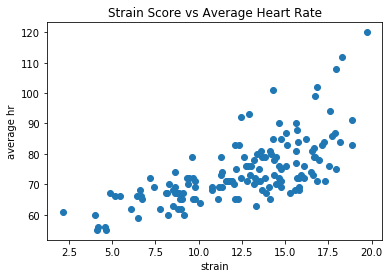

```
The correlation between strain and average hr is: 0.6837964912172086
The covariance between strain and average hr is: 27.736407038609162
```

```python
plotandcorrelate(whoop['calories'], whoop['average hr'], "Calories vs Average Heart Rate")
plotandcorrelate(whoop['strain'], whoop['average hr'], "Strain Score vs Average Heart Rate")
```

When comparing the correlations between strain and calories against average or max heart rate, we see that a higher max heart rate will correlate more strongly with a higher strain, as well as with more calories burned, than a higher average heart rate for the day. From this data, we can conclude that for achieving fitness goals such as weight loss and improving your metabolic rate, both of which require increasing calories burned, high intensity exercise may be more effective than sustained periods of low intensity exercise, for Ben's specific biomarkers. This is an example of Whoop allowing their user's to optimize their performance. By having access to this data, Ben is able to shape the way be trains to be as efficient as possible, by having an understanding of what his body responds most effectively to.

### Strain, Recovery, and Sleep Performance

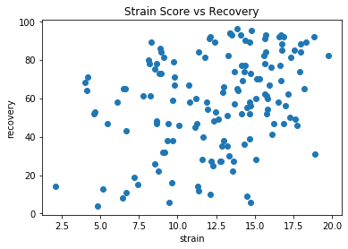

```
The correlation between strain and recovery is: 0.32709643358226864
The covariance between strain and recovery is: 30.80477937165936
```

```python
plotandcorrelate(whoop['strain'], whoop['recovery'], "Strain Score vs Recovery")
```

```
5 Number Summary for strain grouped by recovery type
               count       mean       std       min        25%        50%  \
recovery type
Green           60.0  13.468506  3.625177  3.999910  10.516951  14.230114
Red             28.0  10.514924  3.692576  2.134574   8.227223  11.335176
Yellow          59.0  12.356430  3.750856  4.131985   9.677541  12.982698

                     75%        max
recovery type
Green          16.195891  19.715087
Red            12.933743  18.866295
Yellow         15.366121  18.197569
```

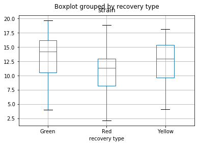

```python
groupedboxplot('strain', 'recovery type')
```

In the above boxplot, strain is grouped by recovery type, and the resulting graphic shows three distinct, but overlapping plots for each recovery type. This insinuates that Ben would strain to a different level given his recovery type. The recovery types, red, yellow, and green represent poor, medium and good levels of recovery. This can signify how well rested or fatigued the wearer is. Whoop uses recovery types in it's GUI as a visual aid, and grouping by scores can show how the wearer responds to this stimulus in the app. While not overly significant, it is important to note that there appears to be some relationship between Ben identifying a green, yellow or red recovery score, and then aiming to optimize his strain based on the score. This is another important indicator that Whoop is allowing Ben to "unlock his human performance".

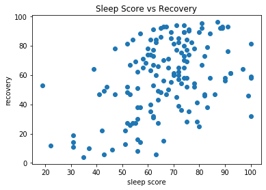

```
The correlation between sleep score and recovery is: 0.4367303186872793
The covariance between sleep score and recovery is: 170.18558382257012
```

```python
plotandcorrelate(whoop['sleep score'], whoop['recovery'], 'Sleep Score vs Recovery')
```

Here, we see Sleep score plotted against recovery, and the two variables have a 0.437 correlation. One might expect these two variables to have a stronger correlation, but this reveals a few things about Whoop's process for calculating sleep score. There must be some other significant variables that are used to dictate recovery score.

```
5 Number Summary for sleep (hr) grouped by day of week
             count      mean       std       min       25%       50%  \
day of week
0 Sun         21.0  6.376371  1.656525  1.773213  5.693700  6.683525
1 Mon         21.0  6.660792  1.052422  4.239195  6.135083  6.622557
2 Tue         21.0  6.623049  1.117359  3.796420  6.321227  6.661043
3 Wed         21.0  6.701703  1.499760  2.975854  6.374441  6.517475
4 Thu         21.0  6.010203  1.690727  2.081219  4.979793  6.268564
5 Fri         21.0  5.767083  1.042739  3.394282  5.241052  5.732474
6 Sat         21.0  6.334992  1.544399  3.464610  5.824712  6.203031

                  75%        max
day of week
0 Sun        6.891531  10.545187
1 Mon        7.357295   9.366868
2 Tue        7.272801   8.824899
3 Wed        7.212361   9.360974
4 Thu        7.257841   8.938532
5 Fri        6.473098   7.478663
6 Sat        7.183780   9.493336
```

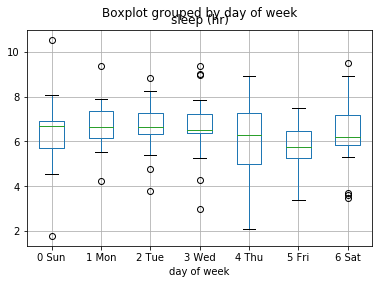

```python
groupedboxplot('sleep (hr)', 'day of week')
```

Here we can see Ben's hours of sleep, grouped by day of the week. Ben has a tendency to sleep more earlier in the week, and less later on in the week, and the boxplots form a very interesting wave-like pattern. This is probably due to Ben's tendency to sleep more consistently earlier in the week. Ben often is more social on thursdays and fridays, and will stay up later as a result. This phenomenon is reflected in the margin of error for Thursday, which is larger than it is on any other day.

```
5 Number Summary for recovery grouped by day of week
             count       mean        std   min   25%   50%   75%   max
day of week
0 Sun         21.0  64.095238  19.934655  28.0  50.0  64.0  78.0  95.0
1 Mon         21.0  65.857143  18.733088  26.0  58.0  63.0  82.0  93.0
2 Tue         21.0  59.761905  23.880755  10.0  41.0  58.0  81.0  92.0
3 Wed         21.0  51.142857  29.567357   6.0  27.0  48.0  82.0  93.0
4 Thu         21.0  60.047619  26.620436  11.0  47.0  65.0  79.0  94.0
5 Fri         21.0  50.285714  25.088130   6.0  30.0  51.0  71.0  94.0
6 Sat         21.0  55.761905  26.164680   4.0  47.0  58.0  77.0  96.0
```

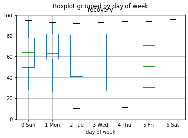

```python
groupedboxplot('recovery', 'day of week')
```

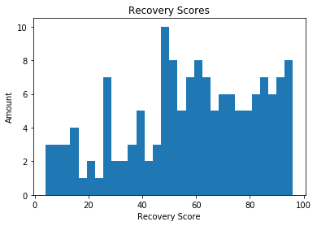

```python
plt.hist(whoop['recovery'], bins = 30)
plt.xlabel("Recovery Score")
plt.ylabel("Amount")
plt.title("Recovery Scores")
plt.show()
```

The distribution of Recovery scores appear to be unimodal, with about a 50 recovery score being most common. As well as this, the data is skewed to the left, indicating that while most recoveries are above 50, there are lower bound outliers. Based on anecdote, Ben assumes these are nights that he does not get to bed at a reasonable hour, and most likely also when he consumes alcohol.

```
5 Number Summary for strain grouped by day of week
             count       mean       std       min        25%        50%  \
day of week
0 Sun         21.0  12.547606  3.423752  4.657497   9.814476  12.429074
1 Mon         21.0  12.628917  3.724457  6.501593   8.830039  13.518367
2 Tue         21.0  14.329919  2.763657  8.632446  12.868519  14.632624
3 Wed         21.0  11.759912  4.153985  2.134574   9.443645  12.355736
4 Thu         21.0  12.663669  4.030952  4.578244   9.765618  13.371322
5 Fri         21.0  12.265723  3.749560  4.183068   9.689355  13.210300
6 Sat         21.0  11.021281  4.368063  3.999910   8.736535   9.817672

                   75%        max
day of week
0 Sun        15.711436  17.250983
1 Mon        15.121997  19.715087
2 Tue        16.511638  18.841313
3 Wed        14.638785  16.731039
4 Thu        16.069004  17.927744
5 Fri        14.299216  18.197569
6 Sat        14.120584  17.959551
```

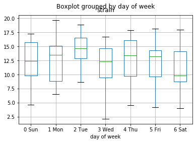

```python
groupedboxplot('strain', 'day of week')
```

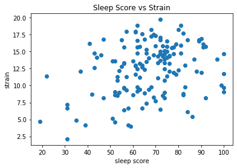

```
The correlation between sleep score and strain is: 0.3063814237633597
The covariance between sleep score and strain is: 18.469982474727974
```

```python
plotandcorrelate(whoop['sleep score'], whoop['strain'], 'Sleep Score vs Strain')
```

The correlation between sleep score and strain was 0.31. In our preregistered analyses, we articulated that we believed this would have a positive correlation, and our predictions were proven correct, although not to the degree that was initially expected. Based on the data, there is a relationship between better sleep and higher strain the following day.

```
Mean squared error: 11.87
Coefficient of determination: 0.08
```

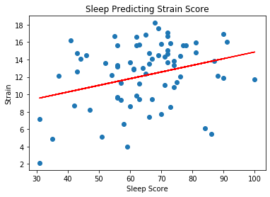

```python
import numpy
from sklearn.linear_model import LinearRegression
from sklearn import datasets, linear_model
from sklearn.metrics import mean_squared_error, r2_score
lreg = LinearRegression()
y =whoop[['strain']]
x =whoop[['sleep score']]
x_train = x[:73]
x_test = x[73:]
y_train = y[:73]
y_test = y[73:]
model = lreg.fit(x_train, y_train)
y_predict = lreg.predict(x_test)
print('Mean squared error: %.2f'
      % mean_squared_error(y_test, y_predict))
print('Coefficient of determination: %.2f'
      % r2_score(y_test, y_predict))
plt.scatter(x_test, y_test)
plt.xlabel("Sleep Score")
plt.ylabel("Strain")
plt.title("Sleep Predicting Strain Score")
plt.plot(x_test, y_predict, color='red')
plt.show()
```

Despite having a low correlation, a linear regression was created to attempt to predict strain scores based on the previous night's sleep score. While the regression line has a slightly positive slope, meaning that a higher sleep score will predict a slightly higher strain, ultimately the coefficient of determination for the regression was very low. To test the predicting ability of the regression, the data for strain and sleep score was split into two parts, a test and training set. The model was trained using the training set, and then attempted to predict the Y values in the test set based on the X values in the test set, which ultimately scored a 0.08 coefficient of determination. This implies that although higher strains and higher sleep scores may correlate together, predicting human activity in as high of a fidelity as we are is a task that most likely requires more sophisticated analyses than a linear regression. It would be interesting to see if based on the data provided in the set, it was possible to design a regression that accurately predicted the following day's strain. The implications of such a predictor could go as far as complicating discussions about human free will.

### HRV, Resting Heart Rate, and Recovery

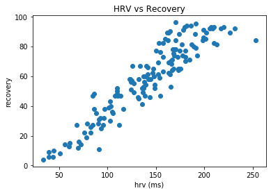

```
The correlation between hrv (ms) and recovery is: 0.9294908030624967
The covariance between hrv (ms) and recovery is: 1050.809377951729
```

```python
plotandcorrelate(whoop['hrv (ms)'], whoop['recovery'], 'HRV vs Recovery')
```

Heart rate variability is a measure of the time between each heart beat, a highly personalized biomarker that differs greatly from person to person. Changes in Heart Rate variability compared to one's baseline are indicators of changing health, but comparing one persons heart rate variability to another's does not elucidate much. In the graph, we see that heart rate variability, measured in milliseconds, and recovery, have a very strong positive correlation of 0.93. This indicates that Whoop uses heart rate variability as one of the primary driving metrics in calculating the recovery score for a given day.

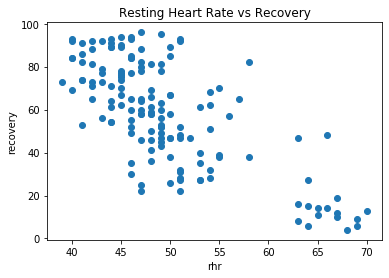

```
The correlation between rhr and recovery is: -0.7255566774705691
The covariance between rhr and recovery is: -128.1246854906346
```

```python
plotandcorrelate(whoop['rhr'], whoop['recovery'], 'Resting Heart Rate vs Recovery')
```

The correlation between resting heart rate and recovery is strongly negatively correlated, with a score of -0.73. This is expected, a higher resting heart rate indicates that the body is working harder to recover from recent strain. Resting heart rate and Heart Rate variability appear to be two of the most important metrics that Whoop uses to calculate a recovery score.

### Sleep duration and Strain

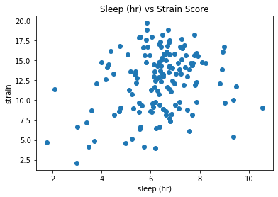

```
The correlation between sleep (hr) and strain is: 0.2504397538769473
The covariance between sleep (hr) and strain is: 1.3457945811585759
```

```python
plotandcorrelate(whoop['sleep (hr)'], whoop['strain'], "Sleep (hr) vs Strain Score")
```

The correlation of 0.25 indicates a weak relationship between strain and sleep in hours. This shows an important concept to remember when attempting to optimize one's training. Although increased sleep will correlate with better recovery and preparation to perform, it does not necessarily mean the user will choose to strain their bodies accordingly. In general, circumstances outside of Whoop data would influence when Ben was able to strain heavily, and therefore, we expected this to have a weak correlation.

### Evaluation of Significance

To evaluate the significance of this data, we will be comparing the first 30 days of Ben's whoop data to his last 30 days. We will test for signficance with heart rate, heart rate variability, and sleep. We chose these markers because Whoop identifies these as indicators of increases in general health, and claims to improve these metrics as a result of purchasing the device. If we prove that Ben has improved in these markers to a significant degree, I.E. more than what could be accredited to random variation, then we can say with confidence that Ben has "unlocked his human performance" by Whoop's definition.

```python
from scipy import stats
import numpy as np
```

```python
first_month = whoop[1:31]
last_month = whoop[len(whoop)-30:]
first_rhr = np.array(first_month["rhr"])
last_rhr = np.array(last_month["rhr"])
first_hrv = np.array(first_month["hrv (ms)"])
last_hrv = np.array(last_month["hrv (ms)"])
first_sleep = np.array(first_month["sleep (hr)"])
last_sleep = np.array(last_month["sleep (hr)"])
```

- Null Hypothesis: Resting Heart Rate from the first and last months are statistically the same.
- alpha level: 0.05
- Alternative Hypothesis: Resting Heart Rate from the first month is statistically different than the last month.

```python
rhr_test = stats.ttest_ind(first_rhr, last_rhr, equal_var = True)
print(rhr_test)
print("The P value is: {}".format(round(rhr_test.pvalue, 2)))
```

```
Ttest_indResult(statistic=-2.0463578186136604, pvalue=0.045263060750928084)
The P value is: 0.05
```

- Null Hypothesis: Heart Rate Variability (milliseconds) from the first and last months are statistically the same.
- alpha level: 0.05
- Alternative Hypothesis: Heart Rate Variability from the first month is statistically different than the last month.

```python
hrv_test = stats.ttest_ind(first_hrv, last_hrv, equal_var = True)
print(hrv_test)
print("The P value is: {}".format(round(hrv_test.pvalue, 2)))
print("The mean hrv of the first month was {} milliseconds".format(round(first_hrv.mean(), 2)))
print("The mean hrv of the last month was {} milliseconds".format(round(last_hrv.mean(), 2)))
```

```
Ttest_indResult(statistic=3.145684719719988, pvalue=0.0026140178632162174)
The P value is: 0.0
The mean hrv of the first month was 161.89 milliseconds
The mean hrv of the last month was 126.82 milliseconds
```

- Null Hypothesis: Sleep duration from the first and last months are statistically the same.
- alpha level: 0.05
- Alternative Hypothesis: Sleep duration from the first month is statistically different from the last month.

```python
sleep_test = stats.ttest_ind(first_sleep, last_sleep, equal_var = True)
print(sleep_test)
print("The P value is: {}".format(round(sleep_test.pvalue, 2)))
```

```
Ttest_indResult(statistic=1.9003071465836956, pvalue=0.06236712331066349)
The P value is: 0.06
```

### Interpretation and Conclusions

Throughout our pre registered analysis question and data analysis, we were not surprised to find a strong correlation between some variables like calories and strain score. Additionally, we more or less correctly predicted which variables will have strong correlations and which will have weaker correlations. This analysis is available above. We are very confident in these conclusions given the accuracy of the Whoop strap, and the size of the samples that we were able to collect. These results affirm our suspicions that a variety of variables are used in the computation of an overall strain score, recovery score, and sleep performance. Of all of the relationships that we examined, the most suprising was the correlation between strain, calories, and max heart rate, or average heart rate. The correlations we discovered led us to believe that for Ben's physiology, high intensity exercise was more effective at increasing the amount of strain and calories he burned in a given day. Another part of the data analysis that we found elucidating was the graphical representation of Ben's sleep for each day of the week with box plots. The representation of how Ben's sleep changed based on his habits on the weekdays or weekends gave us pause, and will most likely lead us to reevaluate our lifestyle choices and put more focus into how we sleep throughout the week.

Whoop can only do so much as it pertains to measuring data of physical ability, which is inevitably what our conclusion must be. Technology like Whoop, that allows us to get a vivid image of our biology and physiology, is very new, and most certainly an imperfect science. Although based on Whoop's metrics, Ben may have gotten unhealthier, we have reason to believe that the opposite is true. For example, Ben increased his squat from 275 pounds for three reps to 330 for three reps over the duration of this data collection. In the bench press, Ben started at 255 pounds for one rep to 265 pounds for three reps. While Ben's biomarkers may not have improved, what did improve was his relationship with exercise, functional fitness, and living a happier and healthier life. Whoop led to a change in mindset: it was not necessarily important how you increased your strain for a given day. It could be dancing, running, lifting weights or riding a bike, and it was all the same to the algorithm. What was important, no matter what the activity was, was elevating the heart rate, sleeping more, drinking less, and choosing healthier habits overall. After experiencing Whoop, this was Ben's final takeaway. While optimizing human performance sounds complex, and daunting, all it really means is to choose healthier lifestyle options, keep your heart rate elevated for a significant period of time every day, and understand your body's physiology in a more nuanced way.

Although Ben failed to unlock his human potential through Whoop's definition, in his own definition, he feels that he has.

### Questions for Reviewers (Phase 2)

List specific questions for your peer reviewers and project mentor to answer in giving you feedback on this phase.

- How can we effectively prove that we have unlocked human performance?
- How do you think we can better prove a scientific and objective assertion that Ben or any other indivdual did in fact complete the Whoop mission statement?
- Was our data analysis clear?
- Did you understand the idea of the recovery and strain score?
- Do any more interesting functions we could write come to mind?
- Do you think we missed any important data limitations that invalidate or discredit our research question?
- Are there any attributes that you don't understand?
- would it be valuable to describe each attribute and for the more complex attributes like strain and recvoery describe the function that creates those outputs?

### Questions for Reviewers (Phase 3)

- Do we accurately and clearly quantify 'unlocking your human performance'?
- In quantifying 'unlocking your human performance', did we adequately justify that there are few, if any, data limitations?
- Did our preregistered analyses expand on our exploratory data analysis enough?
- Did we clearly explain the types of scores and what variables go into the computing of those scores?

### Questions for Reviewers (Phase 4)

- Did we successfully create evaluations of success?
- Did the exploration of the pre registered analyses answer the questions they should have?
- Did that many analyses as opposed to two add to the thoroughness of the project or was it extravagant, and redundant?
- Do you feel that you have a better understanding of human biomarkers, and how they affect general health, after viewing the project?

### Link to raw CSV file

https://docs.google.com/spreadsheets/d/1u9HJ-gczkF5O21IaMMIGXDF4FkMZFpbUF94NR4uXtEY/edit?usp=sharing

### Link to Source Code

https://github.coecis.cornell.edu/pbr48/2950Project